# The Hidden Language of Healthcare Data

## 6. Who Is Building This?

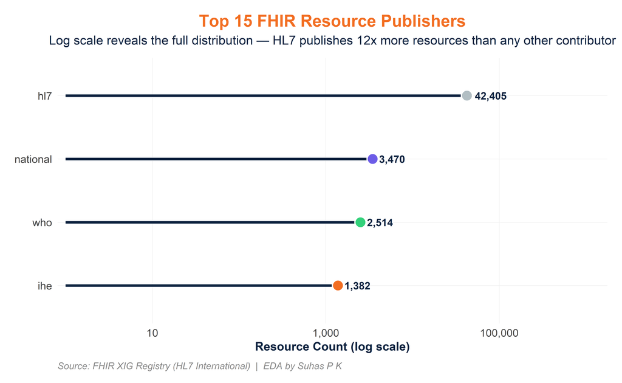

```r
if (!is.null(auth_col)) {
  top_authors <- res %>%
    filter(!is.na(.data[[auth_col]]),
           !.data[[auth_col]] %in% c("", "none", "unknown")) %>%
    count(.data[[auth_col]], sort = TRUE) %>%
    slice_head(n = 15) %>%
    rename(auth = 1) %>%
    mutate(auth = fct_reorder(auth, n))

  # Lollipop + log scale — handles HL7's 12x dominance cleanly
  ggplot(top_authors, aes(x = auth, y = n)) +
    geom_segment(aes(xend = auth, yend = 1),
                 color = HC_NAVY, linewidth = 1.8) +
    geom_point(aes(fill = auth), size = 7, shape = 21,
               color = "white", stroke = 1.5, show.legend = FALSE) +
    geom_text(aes(label = scales::comma(n)),
              hjust = -0.25, fontface = "bold", color = HC_NAVY, size = 5.5) +
    coord_flip() +
    scale_y_log10(labels = scales::comma,
                  expand = expansion(mult = c(0.02, 0.35))) +
    scale_fill_hc() +
    labs(
      title    = "Top 15 FHIR Resource Publishers",
      subtitle = "Log scale reveals the full distribution — HL7 publishes 12x more resources than any other contributor",
      x        = NULL,
      y        = "Resource Count (log scale)",
      caption  = CAPTION
    ) +
    theme_hc()
} else {
  cat("*Author data not available in this dataset.*")
}
```

The publisher landscape tells you exactly who cares about interoperability:

- **HL7 International** — the standards body that *created* FHIR, publishes the canonical resources and the Da Vinci, US Core, and other foundational IGs
- **National government agencies** — CMS, ONC, NHS England, and Australian Digital Health Agency are mandating and publishing reference implementations
- **Industry consortia** — organizations like the Da Vinci Project (a collaboration of payers and providers) are building FHIR IGs for prior authorization, coverage requirements, and clinical data exchange
- **Open source community** — vendors, hospitals, and individual contributors publishing tools and profiles

This mix of regulatory, organizational, and community authorship is a sign of a **healthy, self-sustaining ecosystem** — not one that collapses when a single sponsor stops funding it.

## 7. Status: What’s Active, What’s Retired?

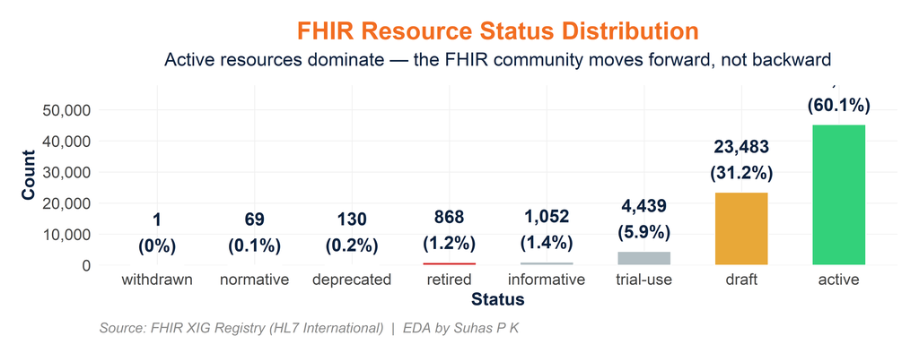

```r
if ("status" %in% names(res)) {
  status_data <- res %>%
    filter(!is.na(status), !status %in% c("", "none", "unknown")) %>%
    count(status, sort = TRUE) %>%
    mutate(
      pct   = round(100 * n / sum(n), 1),
      status = fct_reorder(status, n)
    )

  ggplot(status_data, aes(x = status, y = n, fill = status)) +
    geom_col(show.legend = FALSE, width = 0.55, color = "white") +
    geom_text(aes(label = paste0(scales::comma(n), "\n(", pct, "%)")),
              vjust = -0.35, fontface = "bold", color = HC_NAVY, size = 6.5) +
    scale_y_continuous(labels = scales::comma,
                       expand = expansion(mult = c(0, 0.28))) +
    scale_fill_manual(values = c(
      "active"  = HC_GREEN, "draft"   = HC_GOLD,
      "retired" = HC_RED,   "unknown" = "#b2bec3"
    ), na.value = "#b2bec3") +
    labs(
      title    = "FHIR Resource Status Distribution",
      subtitle = "Active resources dominate — the FHIR community moves forward, not backward",
      x        = "Status",
      y        = "Count",
      caption  = CAPTION
    ) +
    theme_hc()
} else {
  cat("*Status data not available in this dataset.*")
}
```

A high proportion of **active** resources vs retired ones is exactly what you want to see in a growing standard. It means the community is building forward and very rarely has to admit it got something fundamentally wrong. The small retired fraction represents concepts that were either superseded by better-designed replacements or consolidated into existing types — a sign of maturation, not failure.

## 8. Summary — What the Data Tells Us

| Dimension | Finding | Implication |
| --- | --- | --- |
| Version adoption | FHIR R4 accounts for the vast majority of all published resources | Build for R4 first; R5 migration will follow regulatory updates |
| Resource composition | ValueSet + StructureDefinition comprise ~76% of all resource entries | Terminology and profiling are the core workloads of FHIR implementations |
| Geographic reach | The US publishes more FHIR resources than all other nations combined | Regulatory mandate (CMS-9115-F) is the strongest driver of ecosystem growth |
| Vocabulary growth | FHIR resource types grew 67% from R2 (2015) to R6 — from 103 to 172 types | The standard is still actively expanding — implementations must plan for change |
| Author diversity | HL7, government agencies, and industry consortia co-lead the ecosystem | No single failure point; healthy mix of regulatory and community authorship |
| Stability | Active resources dominate; very few are retired | FHIR’s design decisions have held up — the community builds, not rebuilds |

## Why FHIR Is Not Optional for U.S. Healthcare

Here’s the honest version of the story: FHIR didn’t win the healthcare interoperability wars because it was the most technically elegant standard — though it is well-designed. It won because the United States government made it mandatory.

But mandates explain adoption. They don’t explain *momentum*.

The momentum comes from something harder to legislate: **FHIR is actually useful.** When a developer can pull a patient’s 5-year medication history with a single REST API call — the same way they would query a weather API — the abstraction has worked. When a payer can receive a prior authorization request as a structured FHIR resource instead of a fax, the value is immediate and measurable.

This is what a standard looks like when it reaches critical mass.

**For the United States specifically, the stakes are not abstract:**

- The CMS Interoperability and Patient Access Final Rule (CMS-9115-F) mandated FHIR R4 APIs for all Medicare/Medicaid payers — affecting **90+ million beneficiaries**
- The ONC 21st Century Cures Act requires all certified EHR technology to expose FHIR APIs — touching **every hospital and clinic in the country**
- The Prior Authorization rule (CMS-0057-F) mandates FHIR-based prior auth APIs by **January 2027**, potentially saving over **$15 billion annually** in administrative costs
- The Da Vinci Project’s Payer-to-Payer exchange, built entirely on FHIR, enables the continuity of care data to actually follow patients between insurers — a problem that has never been solved at scale before

FHIR is not a technical curiosity. It is the **infrastructure layer of American healthcare data exchange**. And this dataset — every resource, every package, every author — is a living record of the community that is building it.

The healthcare interoperability problem is not solved. But for the first time in history, the industry has agreed on the language it will use to solve it. That agreement, formalized in over 75,411 published resource entries, is the foundation everything else gets built on.

Analysis by **Suhas P K** | Data: FHIR XIG Registry (HL7 International) | Built with R & ggplot2 | March 2026  
📊 [Interactive Shiny Dashboard](https://suhas-pk.shinyapps.io/xig-FHIR-resources-eda/) | 💻 [Source Code on GitHub](https://github.com/suhaspk-health-chain/FHIR-packages-analysis)

### Data & Reproducibility

```r
cat("Dataset: FHIR XIG Registry\n")
## Dataset: FHIR XIG Registry
cat("Total rows:", scales::comma(TOTAL_ROWS), "\n")
## Total rows: 75,411
cat("Total packages:", scales::comma(TOTAL_PACKAGES), "\n")
## Total packages: 1,096
cat("Distinct resource types:", TOTAL_TYPES, "\n")
## Distinct resource types: 23
cat("R version:", R.version$version.string, "\n")
```

```
## R version: R version 4.5.0 (2025-04-11 ucrt)
```

```r
cat("Key packages: dplyr", as.character(packageVersion("dplyr")),
    "| ggplot2", as.character(packageVersion("ggplot2")),
    "| arrow", as.character(packageVersion("arrow")), "\n")
## Key packages: dplyr 1.1.4 | ggplot2 3.5.2 | arrow 21.0.0.1
cat("Report date:", format(Sys.Date(), "%Y-%m-%d"), "\n")
## Report date: 2026-03-07
```

> **To reproduce:** Clone the FHIR-packages-analysis repository, run `eda_plots.R` to generate standalone plots, then knit this `.Rmd` file. All data lives in `data/processed/`.